# Data Analysis - Final Project-Sena

SenaKaya

2023-06-09

#read the dataset #first 5 row

```r
library(readxl)
heartd<- read.csv("/Users/senakaya/Desktop/UCSC/data analysis/final-Personal Key Indicators of Heart Disease/heart_2020_cleaned.csv")
head(heartd)
```

```
##   HeartDisease   BMI Smoking AlcoholDrinking Stroke PhysicalHealth MentalHealth
## 1           No 16.60     Yes              No     No              3           30
## 2           No 20.34      No              No    Yes              0            0
## 3           No 26.58     Yes              No     No             20           30
## 4           No 24.21      No              No     No              0            0
## 5           No 23.71      No              No     No             28            0
## 6          Yes 28.87     Yes              No     No              6            0
##   DiffWalking    Sex AgeCategory  Race Diabetic PhysicalActivity GenHealth
## 1          No Female       55-59 White      Yes              Yes Very good
## 2          No Female 80 or older White       No              Yes Very good
## 3          No   Male       65-69 White      Yes              Yes      Fair
## 4          No Female       75-79 White       No               No      Good
## 5         Yes Female       40-44 White       No              Yes Very good
## 6         Yes Female       75-79 Black       No               No      Fair
##   SleepTime Asthma KidneyDisease SkinCancer
## 1         5    Yes            No        Yes
## 2         7     No            No         No
## 3         8    Yes            No         No
## 4         6     No            No        Yes
## 5         8     No            No         No
## 6        12     No            No         No
```

#dimension of dataset

```r
dim(heartd)
```

```
## [1] 319795     18
```

#to checks number of null values

```r
sum(heartd.stringsAsFactors=FALSE)
```

```
## [1] 0
```

```r
sum(is.na(heartd))
```

```
## [1] 0
```

#a list of objects and their structure

```r
str(heartd)
```

```
## 'data.frame':    319795 obs. of  18 variables:
##  $ HeartDisease    : chr  "No" "No" "No" "No" ...
##  $ BMI             : num  16.6 20.3 26.6 24.2 23.7 ...
##  $ Smoking         : chr  "Yes" "No" "Yes" "No" ...
##  $ AlcoholDrinking : chr  "No" "No" "No" "No" ...
##  $ Stroke          : chr  "No" "Yes" "No" "No" ...
##  $ PhysicalHealth  : num  3 0 20 0 28 6 15 5 0 0 ...
##  $ MentalHealth    : num  30 0 30 0 0 0 0 0 0 0 ...
##  $ DiffWalking     : chr  "No" "No" "No" "No" ...
##  $ Sex             : chr  "Female" "Female" "Male" "Female" ...
##  $ AgeCategory     : chr  "55-59" "80 or older" "65-69" "75-79" ...
##  $ Race            : chr  "White" "White" "White" "White" ...
##  $ Diabetic        : chr  "Yes" "No" "Yes" "No" ...
##  $ PhysicalActivity: chr  "Yes" "Yes" "Yes" "No" ...
##  $ GenHealth       : chr  "Very good" "Very good" "Fair" "Good" ...
##  $ SleepTime       : num  5 7 8 6 8 12 4 9 5 10 ...
##  $ Asthma          : chr  "Yes" "No" "Yes" "No" ...
##  $ KidneyDisease   : chr  "No" "No" "No" "No" ...
##  $ SkinCancer      : chr  "Yes" "No" "No" "Yes" ...
```

#summary of the dataset

```r
summary(heartd)
```

```
##  HeartDisease            BMI          Smoking          AlcoholDrinking
##  Length:319795      Min.   :12.02   Length:319795      Length:319795
##  Class :character   1st Qu.:24.03   Class :character   Class :character
##  Mode  :character   Median :27.34   Mode  :character   Mode  :character
##                     Mean   :28.33
##                     3rd Qu.:31.42
##                     Max.   :94.85
##     Stroke          PhysicalHealth    MentalHealth    DiffWalking
##  Length:319795      Min.   : 0.000   Min.   : 0.000   Length:319795
##  Class :character   1st Qu.: 0.000   1st Qu.: 0.000   Class :character
##  Mode  :character   Median : 0.000   Median : 0.000   Mode  :character
##                     Mean   : 3.372   Mean   : 3.898
##                     3rd Qu.: 2.000   3rd Qu.: 3.000
##                     Max.   :30.000   Max.   :30.000
##      Sex            AgeCategory            Race             Diabetic
##  Length:319795      Length:319795      Length:319795      Length:319795
##  Class :character   Class :character   Class :character   Class :character
##  Mode  :character   Mode  :character   Mode  :character   Mode  :character
##
##
##
##  PhysicalActivity    GenHealth           SleepTime         Asthma
##  Length:319795      Length:319795      Min.   : 1.000   Length:319795
##  Class :character   Class :character   1st Qu.: 6.000   Class :character
##  Mode  :character   Mode  :character   Median : 7.000   Mode  :character
##                                        Mean   : 7.097
##                                        3rd Qu.: 8.000
##                                        Max.   :24.000
##  KidneyDisease       SkinCancer
##  Length:319795      Length:319795
##  Class :character   Class :character
##  Mode  :character   Mode  :character
##
##
##
```

#table of HeartDisease

```r
table(heartd$HeartDisease)
```

```
##
##     No    Yes
## 292422  27373
```

#the number of different values for each column

```r
library(dplyr)
heartd %>% summarise_all(n_distinct)
```

```
##   HeartDisease  BMI Smoking AlcoholDrinking Stroke PhysicalHealth MentalHealth
## 1            2 3604       2               2      2             31           31
##   DiffWalking Sex AgeCategory Race Diabetic PhysicalActivity GenHealth
## 1           2   2          13    6        4                2         5
##   SleepTime Asthma KidneyDisease SkinCancer
## 1        24      2             2          2
```

#EDA (EXPLORATORY DATA ANALYSIS) #histogram of BMI(Body Mass Index)

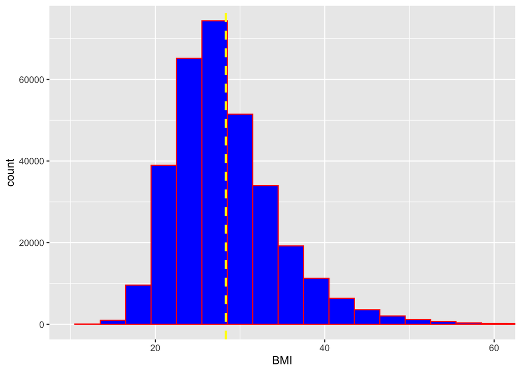

```r
library(ggplot2)

p<-ggplot(data = heartd, aes(x = BMI)) + geom_histogram(binwidth = 3,fill='blue',colour="red")+ coord_cartesian(xlim = c(10, 60))
p+ geom_vline(aes(xintercept=mean(BMI)), color="yellow", linetype="dashed", linewidth=1)
```

#histogram of Physical Health

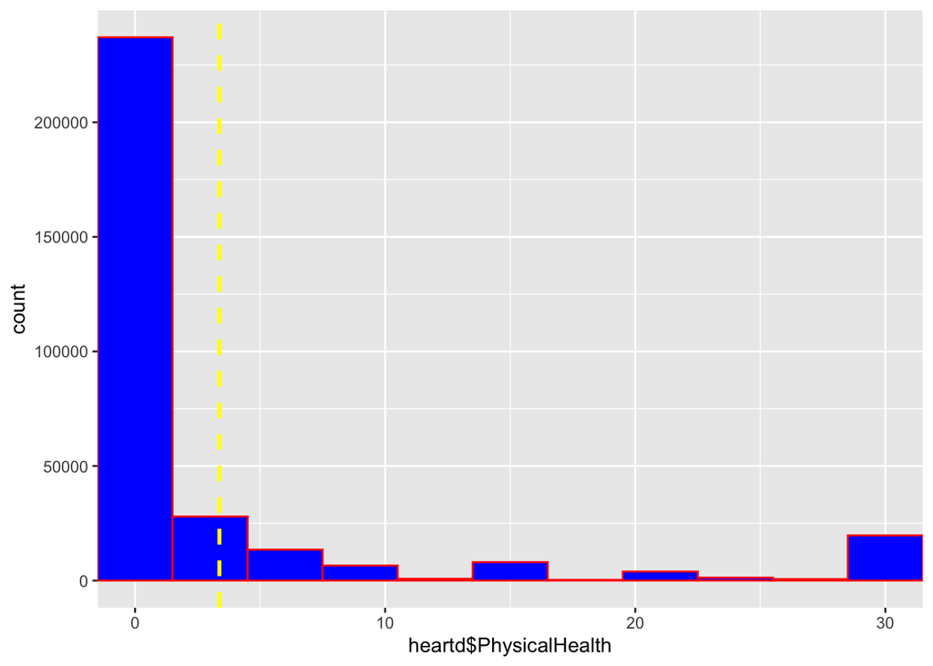

```r
p<-ggplot(data = heartd, aes(x = heartd$PhysicalHealth)) + geom_histogram(binwidth = 3,fill='blue',colour="red")+ coord_cartesian(xlim = c(0, 30))
p+ geom_vline(aes(xintercept=mean(heartd$PhysicalHealth)), color="yellow", linetype="dashed", size=1)
```

#histogram of Mental Health

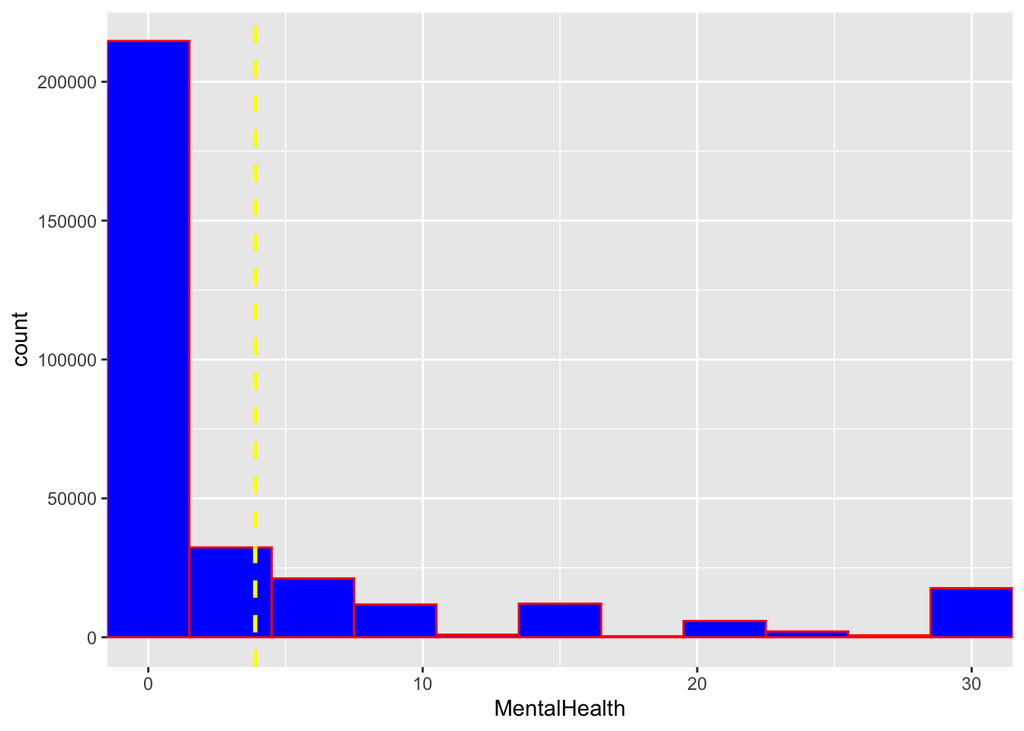

```r
p<-ggplot(data = heartd, aes(x = MentalHealth )) + geom_histogram(binwidth = 3,fill='blue',colour="red")+ coord_cartesian(xlim = c(0, 30))
p+ geom_vline(aes(xintercept=mean(MentalHealth)), color="yellow", linetype="dashed", size=1)
```

#histogram of Sleep Time

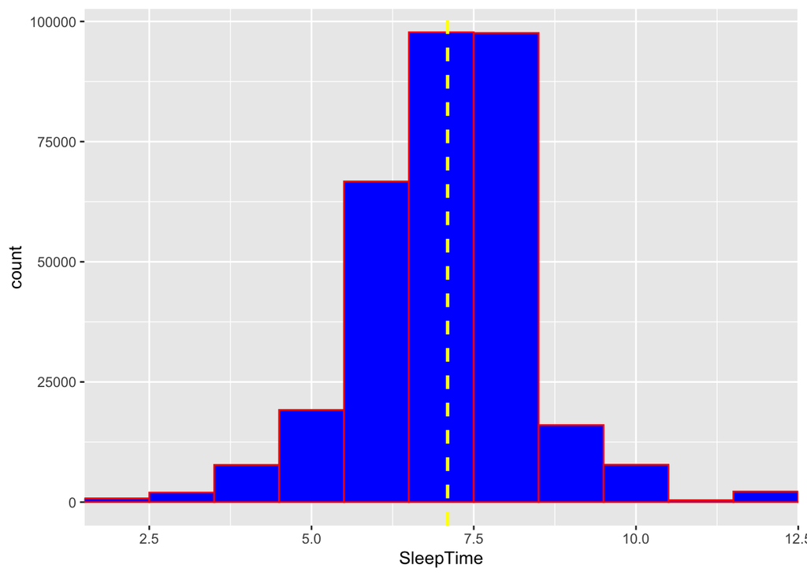

```r
p<-ggplot(data = heartd, aes(x = SleepTime)) + geom_histogram(binwidth = 1,fill='blue',colour="red")+ coord_cartesian(xlim = c(2, 12))
p+ geom_vline(aes(xintercept=mean(SleepTime)), color="yellow", linetype="dashed", size=1)
```

#remove the scientific notations from the axis

```r
options(scipen = 999)
```

#Create the stacked bar plot for two categorical variable heart disease and smoking

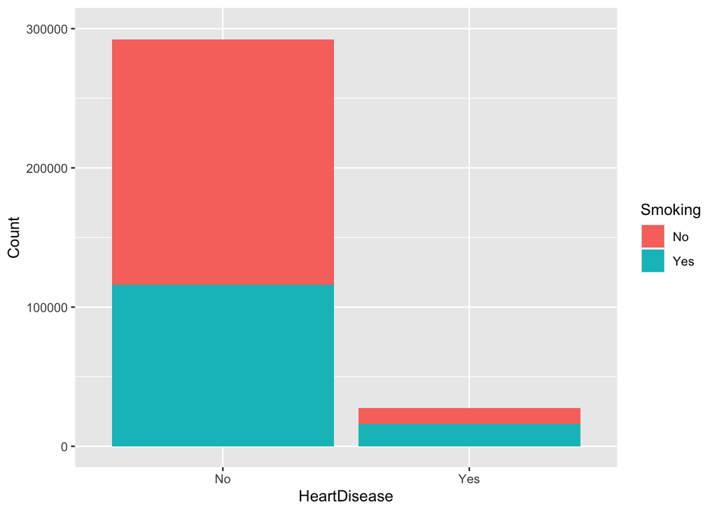

```r
ggplot(heartd, aes(x = HeartDisease, fill = Smoking)) +
  geom_bar() +
  xlab("HeartDisease") +
  ylab("Count") +
  coord_cartesian(ylim = c(0, 300000))
```

```r
  ggtitle("Bar Plot of Heart Disease and Smoking")
```

```
## $title
## [1] "Bar Plot of Heart Disease and Smoking"
##
## attr(,"class")
## [1] "labels"
```

#Create the stacked bar plot for two categorical variable heart disease and alcohol drinking

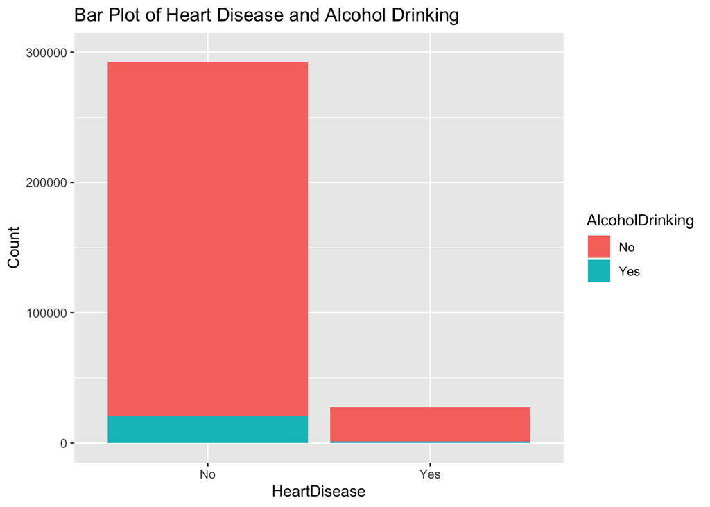

```r
ggplot(heartd, aes(x = HeartDisease, fill = AlcoholDrinking)) +
  geom_bar() +
  xlab("HeartDisease") +
  ylab("Count") +
  coord_cartesian(ylim = c(0, 300000))+
  ggtitle("Bar Plot of Heart Disease and Alcohol Drinking")
```

#Create the bar stacked plot for two categorical variable heart disease and sex

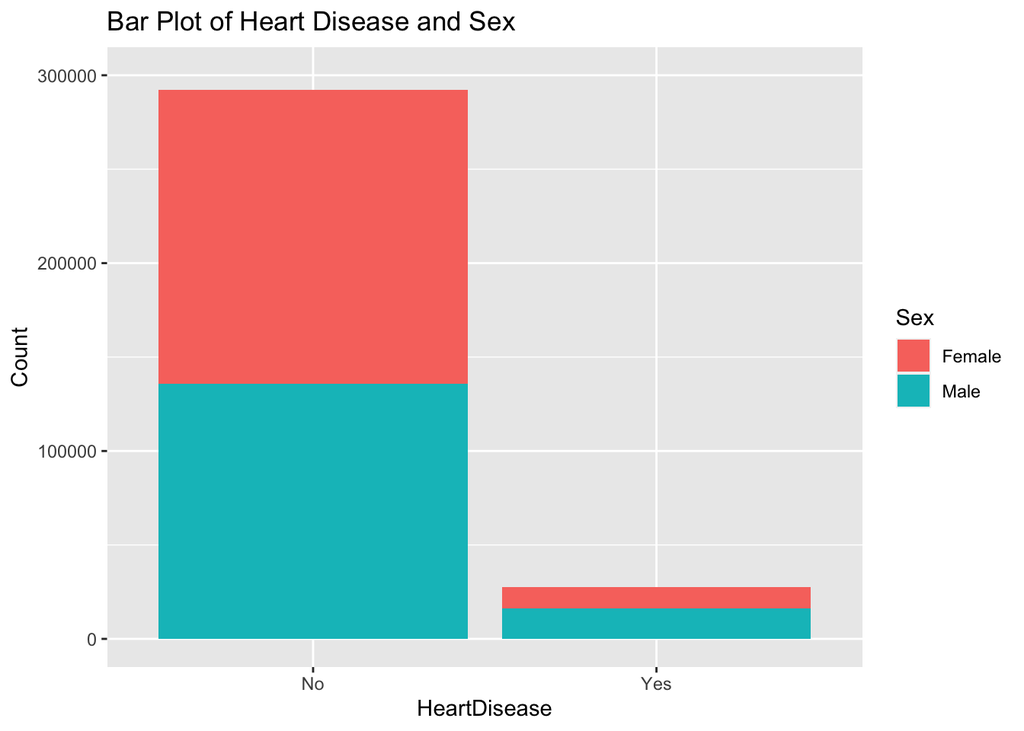

```r
ggplot(heartd, aes(x = HeartDisease, fill = Sex)) +
  geom_bar() +
  xlab("HeartDisease") +
  ylab("Count") +
  coord_cartesian(ylim = c(0, 300000))+
  ggtitle("Bar Plot of Heart Disease and Sex")
```

#Create the stacked bar plot for two categorical variable heart disease and asthma

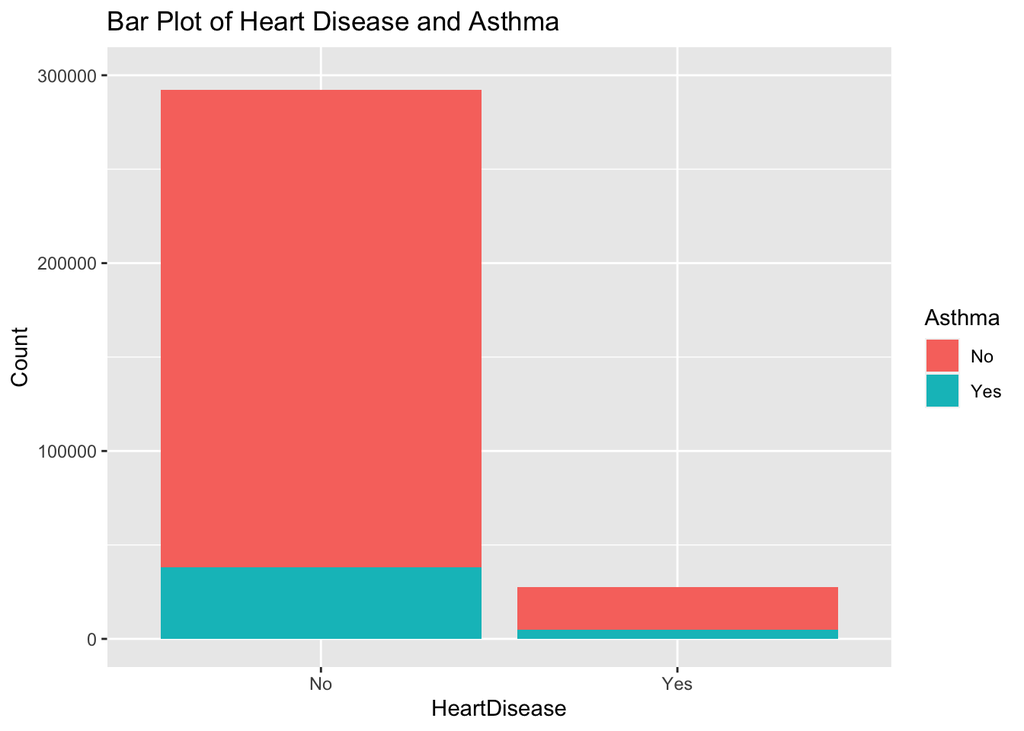

```r
ggplot(heartd, aes(x = HeartDisease, fill = Asthma)) +
  geom_bar() +
  xlab("HeartDisease") +
  ylab("Count") +
  coord_cartesian(ylim = c(0, 300000))+
  ggtitle("Bar Plot of Heart Disease and Asthma")
```

#Create the stacked bar plot for two categorical variable heart disease and kidney disease

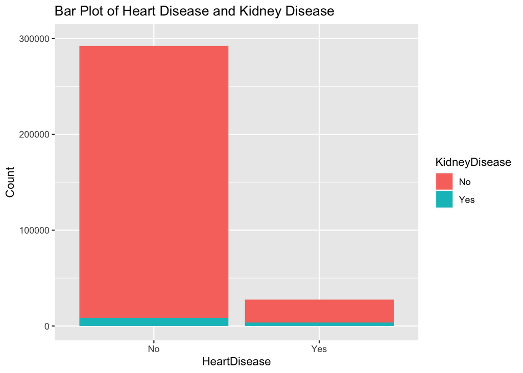

```r
ggplot(heartd, aes(x = HeartDisease, fill = KidneyDisease)) +
  geom_bar() +
  xlab("HeartDisease") +
  ylab("Count") +
  coord_cartesian(ylim = c(0, 300000))+
  ggtitle("Bar Plot of Heart Disease and Kidney Disease")
```

#Create the stacked bar plot for two categorical variable heart disease and skin cancer

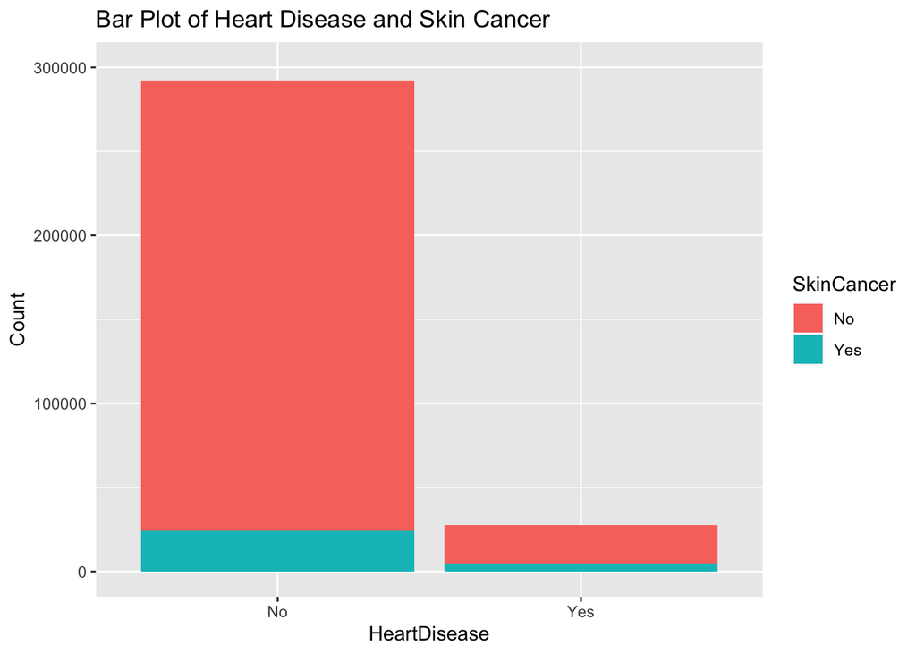

```r
ggplot(heartd, aes(x = HeartDisease, fill = SkinCancer)) +
  geom_bar() +
  xlab("HeartDisease") +
  ylab("Count") +
  coord_cartesian(ylim = c(0, 300000))+
  ggtitle("Bar Plot of Heart Disease and Skin Cancer")
```

#Count the frequencies of each combination of the two variables #Create the bar chart

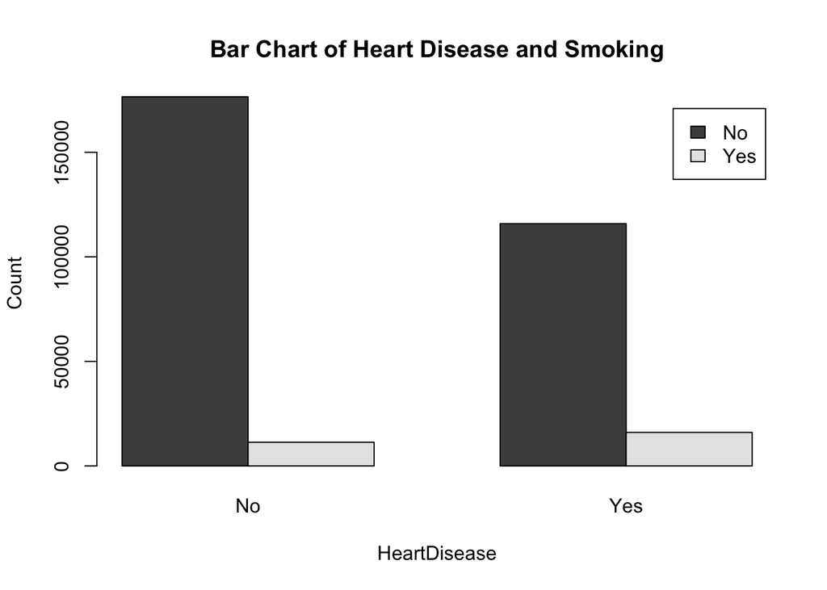

```r
counts <- table(heartd$HeartDisease, heartd$Smoking)

barplot(counts, beside = TRUE, legend = TRUE,
        xlab = "HeartDisease", ylab = "Count",
        main = "Bar Chart of Heart Disease and Smoking")
```

#Count the frequencies of each combination of the two variables #Define colors for the bars #Create the bar chart

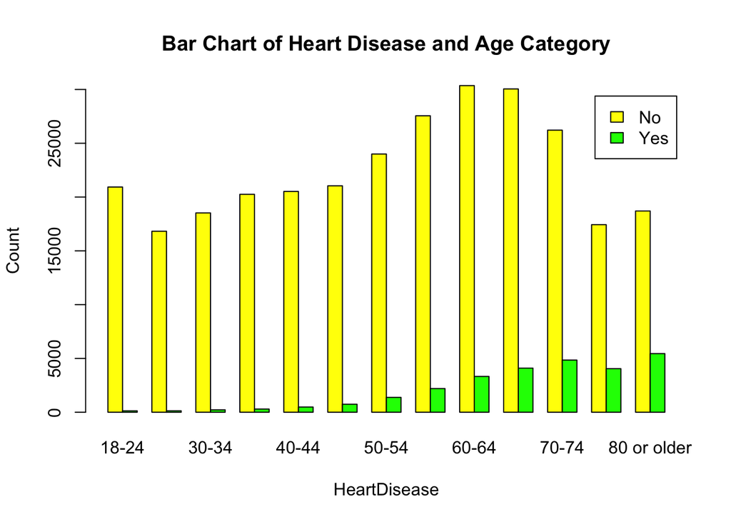

```r
counts <- table(heartd$HeartDisease, heartd$AgeCategory)

colors <- c("yellow", "green")

barplot(counts, beside = TRUE, legend = TRUE,
        xlab = "HeartDisease", ylab = "Count",
        main = "Bar Chart of Heart Disease and Age Category", col = colors)
```

#Count the frequencies of each combination of the two variables

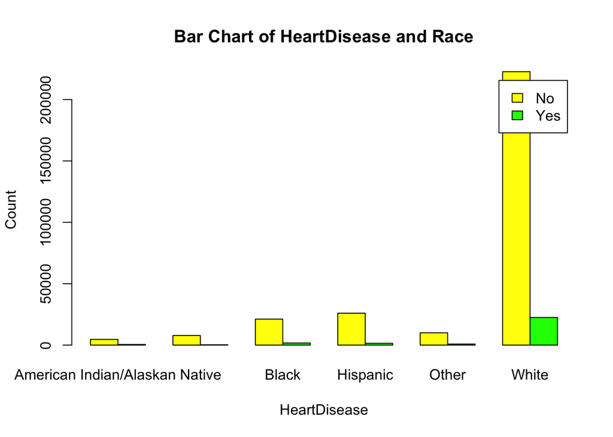

```r
counts <- table(heartd$HeartDisease, heartd$Race)

colors <- c("yellow", "green")

barplot(counts, beside = TRUE, legend = TRUE,
        xlab = "HeartDisease", ylab = "Count",
        main = "Bar Chart of HeartDisease and Race", col = colors)
```

#Count the frequencies of each combination of the two variables

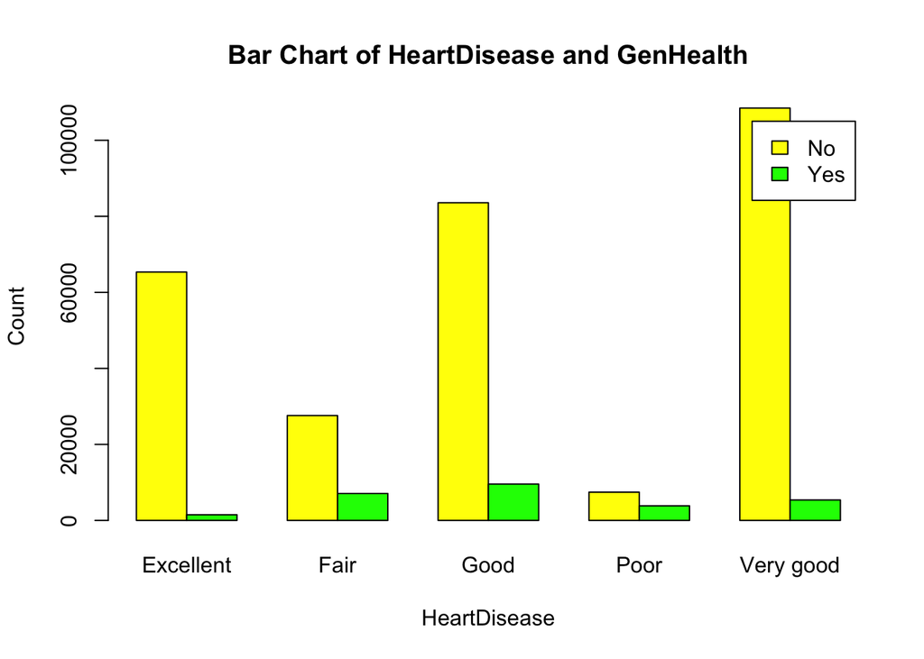

```r
counts <- table(heartd$HeartDisease, heartd$GenHealth)

colors <- c("yellow", "green")

barplot(counts, beside = TRUE, legend = TRUE,
        xlab = "HeartDisease", ylab = "Count",
        main = "Bar Chart of HeartDisease and GenHealth", col = colors)
```

# Count the frequencies of each combination of the two variables

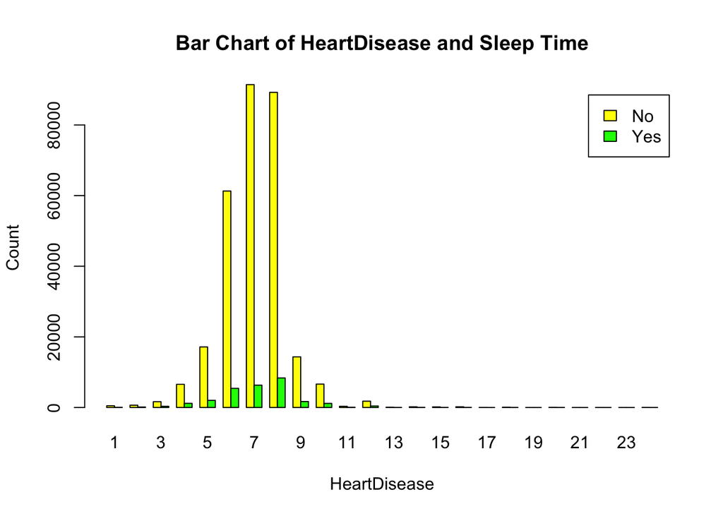

```r
counts <- table(heartd$HeartDisease, heartd$SleepTime)

colors <- c("yellow", "green")

barplot(counts, beside = TRUE, legend = TRUE,
        xlab = "HeartDisease", ylab = "Count",
        main = "Bar Chart of HeartDisease and Sleep Time", col = colors)
```

# Count the frequencies of each combination of the two variables

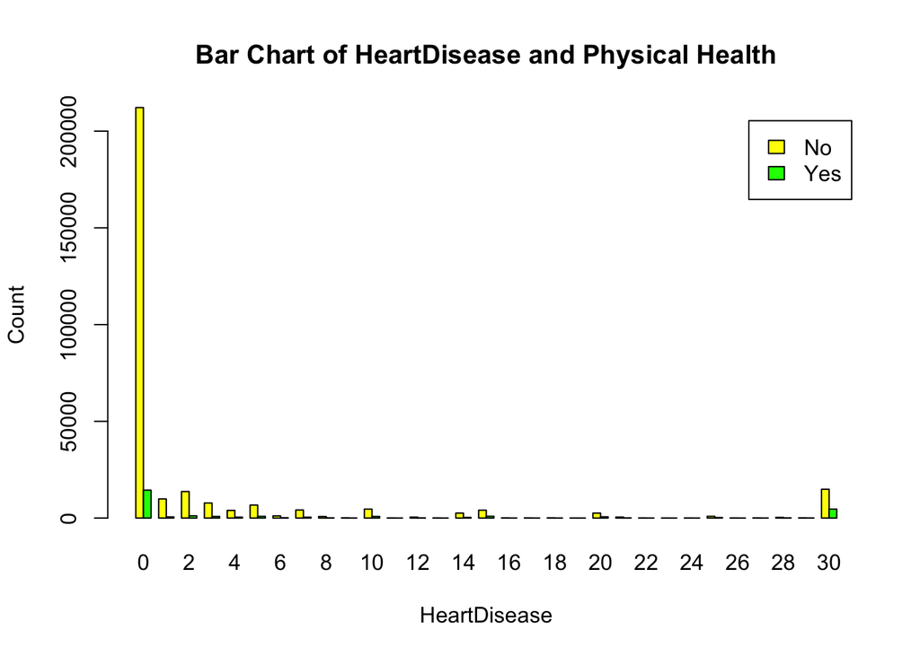

```r
counts <- table(heartd$HeartDisease, heartd$PhysicalHealth)

colors <- c("yellow", "green")

barplot(counts, beside = TRUE, legend = TRUE,
        xlab = "HeartDisease", ylab = "Count",
        main = "Bar Chart of HeartDisease and Physical Health", col = colors)
```

# Replace values in the data frame

```r
heartd <- replace(heartd, heartd == 'Yes', 1)
heartd <- replace(heartd, heartd == 'No', 0)
heartd <- replace(heartd, heartd == 'Male', 1)
heartd <- replace(heartd, heartd == 'Female', 0)
heartd <- replace(heartd, heartd == 'No, borderline diabetes', 0)
heartd <- replace(heartd, heartd == 'Yes (during pregnancy)', 1)
#ordinal
heartd <- replace(heartd, heartd == 'Excellent', 5)
heartd <- replace(heartd, heartd == 'Very good', 4)
heartd <- replace(heartd, heartd == 'Good', 3)
heartd <- replace(heartd, heartd == 'Fair', 2)
heartd <- replace(heartd, heartd == 'Poor', 1)
```

# Convert ‘Diabetic’ column to integer

```r
heartd$Diabetic <- as.numeric(heartd$Diabetic)
```

# Extract the first two characters from the “Age” column

```r
heartd$AgeCategory <- substr(heartd$AgeCategory, 1, 2)
```

# Print the first five row of modified “Age” column

```r
print(heartd$AgeCategory[1:5])
```

```
## [1] "55" "80" "65" "75" "40"
```

#convert all “0”s and “1”s to integer except c( “Race”)

```r
num_columns <- setdiff(colnames(heartd), c( "Race"))

heartd_num <- as.data.frame(lapply(heartd[num_columns], as.numeric))

str(heartd_num)
```

```
## 'data.frame':    319795 obs. of  17 variables:
##  $ HeartDisease    : num  0 0 0 0 0 1 0 0 0 0 ...
##  $ BMI             : num  16.6 20.3 26.6 24.2 23.7 ...
##  $ Smoking         : num  1 0 1 0 0 1 0 1 0 0 ...
##  $ AlcoholDrinking : num  0 0 0 0 0 0 0 0 0 0 ...
##  $ Stroke          : num  0 1 0 0 0 0 0 0 0 0 ...
##  $ PhysicalHealth  : num  3 0 20 0 28 6 15 5 0 0 ...
##  $ MentalHealth    : num  30 0 30 0 0 0 0 0 0 0 ...
##  $ DiffWalking     : num  0 0 0 0 1 1 0 1 0 1 ...
##  $ Sex             : num  0 0 1 0 0 0 0 0 0 1 ...
##  $ AgeCategory     : num  55 80 65 75 40 75 70 80 80 65 ...
##  $ Diabetic        : num  1 0 1 0 0 0 0 1 0 0 ...
##  $ PhysicalActivity: num  1 1 1 0 1 0 1 0 0 1 ...
##  $ GenHealth       : num  4 4 2 3 4 2 2 3 2 3 ...
##  $ SleepTime       : num  5 7 8 6 8 12 4 9 5 10 ...
##  $ Asthma          : num  1 0 1 0 0 0 1 1 0 0 ...
##  $ KidneyDisease   : num  0 0 0 0 0 0 0 0 1 0 ...
##  $ SkinCancer      : num  1 0 0 1 0 0 1 0 0 0 ...
```

```r
library(reshape2)
library(RColorBrewer)
library(corrplot)
library(ggcorrplot)
```

#Create correlation matrix #Plot correlation matrix #Calculate the correlation matrix

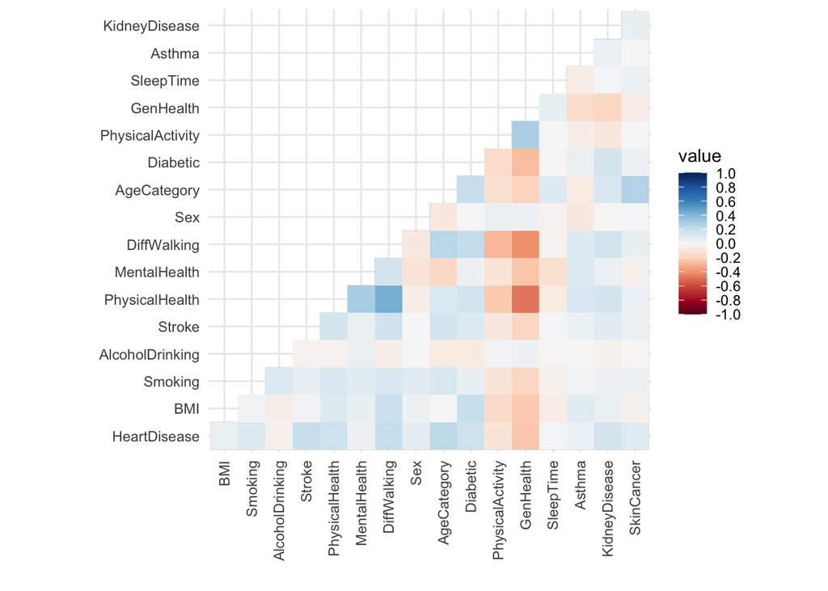

```r
cor_matrix <- cor(heartd_num)

ggcorrplot(cor_matrix, type = "lower") +
  geom_tile() +
  scale_fill_gradientn(colours = brewer.pal(11, "RdBu"),
                       limits = c(-1, 1),
                       breaks = seq(-1, 1, by = 0.2)) +

  labs(x = "", y = "") +
  theme_minimal() +
  theme(axis.text.x = element_text(angle = 90, vjust = 0.5, hjust=1))
```

```r
cor_matrix <- cor(heartd_num)

print(cor_matrix)
```

```
##                  HeartDisease          BMI     Smoking AlcoholDrinking
## HeartDisease      1.000000000  0.051803191  0.10776416    -0.032079743
## BMI               0.051803191  1.000000000  0.02311811    -0.038816223
## Smoking           0.107764156  0.023118112  1.00000000     0.111767520
## AlcoholDrinking  -0.032079743 -0.038816223  0.11176752     1.000000000
## Stroke            0.196835299  0.019732982  0.06122604    -0.019857914
## PhysicalHealth    0.170720972  0.109787544  0.11535241    -0.017254288
## MentalHealth      0.028590715  0.064130569  0.08515729     0.051281973
## DiffWalking       0.201258049  0.181678264  0.12007416    -0.035327583
## Sex               0.070040476  0.026939645  0.08505249     0.004200142
## AgeCategory       0.232324637 -0.001740121  0.13038380    -0.058836643
## Diabetic          0.174782320  0.200442834  0.05554379    -0.057786229
## PhysicalActivity -0.100029934 -0.150615994 -0.09717377     0.017486983
## GenHealth        -0.243182458 -0.230719780 -0.17471733     0.029780388
## SleepTime         0.008326647 -0.051822254 -0.03033564    -0.005065451
## Asthma            0.041444151  0.092345019  0.02414853    -0.002202100
## KidneyDisease     0.145197099  0.050767533  0.03491969    -0.028280092
## SkinCancer        0.093316878 -0.033643619  0.03397739    -0.005702370
##                        Stroke PhysicalHealth MentalHealth DiffWalking
## HeartDisease      0.196835299     0.17072097   0.02859071  0.20125805
## BMI               0.019732982     0.10978754   0.06413057  0.18167826
## Smoking           0.061226040     0.11535241   0.08515729  0.12007416
## AlcoholDrinking  -0.019857914    -0.01725429   0.05128197 -0.03532758
## Stroke            1.000000000     0.13701383   0.04646706  0.17414321
## PhysicalHealth    0.137013827     1.00000000   0.28798667  0.42837280
## MentalHealth      0.046467061     0.28798667   1.00000000  0.15223467
## DiffWalking       0.174143214     0.42837280   0.15223467  1.00000000
## Sex              -0.003091055    -0.04090384  -0.10005847 -0.06885956
## AgeCategory       0.137279527     0.11078930  -0.15545468  0.24255230
## Diabetic          0.104466795     0.15397533   0.02970857  0.20925469
## PhysicalActivity -0.079455195    -0.23228318  -0.09580810 -0.27852396
## GenHealth        -0.168090049    -0.48269718  -0.24162528 -0.41379735
## SleepTime         0.011899981    -0.06138663  -0.11971679 -0.02221636
## Asthma            0.038866140     0.11790658   0.11400817  0.10322205
## KidneyDisease     0.091166841     0.14219718   0.03728113  0.15306375
## SkinCancer        0.048116104     0.04169969  -0.03341219  0.06484040
##                           Sex  AgeCategory     Diabetic PhysicalActivity
## HeartDisease      0.070040476  0.232324637  0.174782320     -0.100029934
## BMI               0.026939645 -0.001740121  0.200442834     -0.150615994
## Smoking           0.085052486  0.130383805  0.055543794     -0.097173766
```

[output cut: 35 more lines]

```
## Smoking           0.0339773873
## AlcoholDrinking  -0.0057023705
## Stroke            0.0481161045
## PhysicalHealth    0.0416996855
## MentalHealth     -0.0334121907
## DiffWalking       0.0648404018
## Sex               0.0134337997
## AgeCategory       0.2622076094
## Diabetic          0.0340773087
## PhysicalActivity -0.0013278105
## GenHealth        -0.0506413674
## SleepTime         0.0412661675
## Asthma           -0.0003964769
## KidneyDisease     0.0618162165
## SkinCancer        1.0000000000
```

#Find correlations above 0.75 #Check if there are any high correlations

```r
high_corr <- which(cor_matrix > 0.75 & cor_matrix < 1, arr.ind = TRUE)

if (nrow(high_corr) == 0) {
  cat("No correlations above 0.75 found.\n")
} else {
  # Print the pairs of variables with high correlation
  for (i in 1:nrow(high_corr)) {
    row_num <- high_corr[i, "row"]
    col_num <- high_corr[i, "col"]
    row_name <- rownames(cor_matrix)[row_num]
    col_name <- colnames(cor_matrix)[col_num]
    correlation <- cor_matrix[row_num, col_num]
    cat("High correlation (", correlation, ") between", row_name, "and", col_name, "\n")
  }
}
```

```
## No correlations above 0.75 found.
```

#Create a copy of the original data frame

```r
df_encoded <- heartd
str(df_encoded)
```

```
## 'data.frame':    319795 obs. of  18 variables:
##  $ HeartDisease    : chr  "0" "0" "0" "0" ...
##  $ BMI             : num  16.6 20.3 26.6 24.2 23.7 ...
##  $ Smoking         : chr  "1" "0" "1" "0" ...
##  $ AlcoholDrinking : chr  "0" "0" "0" "0" ...
##  $ Stroke          : chr  "0" "1" "0" "0" ...
##  $ PhysicalHealth  : num  3 0 20 0 28 6 15 5 0 0 ...
##  $ MentalHealth    : num  30 0 30 0 0 0 0 0 0 0 ...
##  $ DiffWalking     : chr  "0" "0" "0" "0" ...
##  $ Sex             : chr  "0" "0" "1" "0" ...
##  $ AgeCategory     : chr  "55" "80" "65" "75" ...
##  $ Race            : chr  "White" "White" "White" "White" ...
##  $ Diabetic        : num  1 0 1 0 0 0 0 1 0 0 ...
##  $ PhysicalActivity: chr  "1" "1" "1" "0" ...
##  $ GenHealth       : chr  "4" "4" "2" "3" ...
##  $ SleepTime       : num  5 7 8 6 8 12 4 9 5 10 ...
##  $ Asthma          : chr  "1" "0" "1" "0" ...
##  $ KidneyDisease   : chr  "0" "0" "0" "0" ...
##  $ SkinCancer      : chr  "1" "0" "0" "1" ...
```

#ONE-HOT ENCODING #Perform one-hot encoding for the “Race” column

```r
df_encoded <- heartd
```

#Extract the “Race” column

```r
race_column <- df_encoded$Race
```

#Perform one-hot encoding for the “Race” column

```r
encoded_cols <- model.matrix(~ 0 + factor(race_column))
colnames(encoded_cols) <- paste("Race", colnames(encoded_cols), sep = "_")
```

#Add the encoded columns to the data set

```r
df_encoded <- cbind(df_encoded, encoded_cols)
```

#Remove the original “Race” column

```r
df_encoded <- df_encoded[, !names(df_encoded) %in% "Race"]
```

#Print the encoded data set

```r
print(head(df_encoded))
```

```
##   HeartDisease   BMI Smoking AlcoholDrinking Stroke PhysicalHealth MentalHealth
## 1            0 16.60       1               0      0              3           30
## 2            0 20.34       0               0      1              0            0
## 3            0 26.58       1               0      0             20           30
## 4            0 24.21       0               0      0              0            0
## 5            0 23.71       0               0      0             28            0
## 6            1 28.87       1               0      0              6            0
##   DiffWalking Sex AgeCategory Diabetic PhysicalActivity GenHealth SleepTime
## 1           0   0          55        1                1         4         5
## 2           0   0          80        0                1         4         7
## 3           0   1          65        1                1         2         8
## 4           0   0          75        0                0         3         6
## 5           1   0          40        0                1         4         8
## 6           1   0          75        0                0         2        12
##   Asthma KidneyDisease SkinCancer
```

[output cut: 34 more lines]

```r
str(df_encoded)
```

```
## 'data.frame':    319795 obs. of  23 variables:
##  $ HeartDisease                                          : chr  "0" "0" "0" "0" ...
##  $ BMI                                                   : num  16.6 20.3 26.6 24.2 23.7 ...
##  $ Smoking                                               : chr  "1" "0" "1" "0" ...
##  $ AlcoholDrinking                                       : chr  "0" "0" "0" "0" ...
##  $ Stroke                                                : chr  "0" "1" "0" "0" ...
##  $ PhysicalHealth                                        : num  3 0 20 0 28 6 15 5 0 0 ...
##  $ MentalHealth                                          : num  30 0 30 0 0 0 0 0 0 0 ...
##  $ DiffWalking                                           : chr  "0" "0" "0" "0" ...
##  $ Sex                                                   : chr  "0" "0" "1" "0" ...
##  $ AgeCategory                                           : chr  "55" "80" "65" "75" ...
##  $ Diabetic                                              : num  1 0 1 0 0 0 0 1 0 0 ...
##  $ PhysicalActivity                                      : chr  "1" "1" "1" "0" ...
##  $ GenHealth                                             : chr  "4" "4" "2" "3" ...
##  $ SleepTime                                             : num  5 7 8 6 8 12 4 9 5 10 ...
##  $ Asthma                                                : chr  "1" "0" "1" "0" ...
##  $ KidneyDisease                                         : chr  "0" "0" "0" "0" ...
##  $ SkinCancer                                            : chr  "1" "0" "0" "1" ...
##  $ Race_factor(race_column)American Indian/Alaskan Native: num  0 0 0 0 0 0 0 0 0 0 ...
##  $ Race_factor(race_column)Asian                         : num  0 0 0 0 0 0 0 0 0 0 ...
##  $ Race_factor(race_column)Black                         : num  0 0 0 0 0 1 0 0 0 0 ...
##  $ Race_factor(race_column)Hispanic                      : num  0 0 0 0 0 0 0 0 0 0 ...
##  $ Race_factor(race_column)Other                         : num  0 0 0 0 0 0 0 0 0 0 ...
##  $ Race_factor(race_column)White                         : num  1 1 1 1 1 0 1 1 1 1 ...
```

#Convert specific columns to integers (only independent variables - dependent variable must be a factor)

```r
columns_to_convert <- c("Smoking", "SkinCancer", "KidneyDisease", "Asthma", "GenHealth",
                        "AgeCategory","Stroke", "AlcoholDrinking","Sex", "DiffWalking", "PhysicalActivity")
df_encoded[columns_to_convert] <- lapply(df_encoded[columns_to_convert], as.numeric)
```

#Identify numeric variables in the data frame

```r
numeric_vars <- sapply(df_encoded, is.numeric)

str(df_encoded)
```

```
## 'data.frame':    319795 obs. of  23 variables:
##  $ HeartDisease                                          : chr  "0" "0" "0" "0" ...
##  $ BMI                                                   : num  16.6 20.3 26.6 24.2 23.7 ...
##  $ Smoking                                               : num  1 0 1 0 0 1 0 1 0 0 ...
##  $ AlcoholDrinking                                       : num  0 0 0 0 0 0 0 0 0 0 ...
##  $ Stroke                                                : num  0 1 0 0 0 0 0 0 0 0 ...
##  $ PhysicalHealth                                        : num  3 0 20 0 28 6 15 5 0 0 ...
##  $ MentalHealth                                          : num  30 0 30 0 0 0 0 0 0 0 ...
##  $ DiffWalking                                           : num  0 0 0 0 1 1 0 1 0 1 ...
##  $ Sex                                                   : num  0 0 1 0 0 0 0 0 0 1 ...
##  $ AgeCategory                                           : num  55 80 65 75 40 75 70 80 80 65 ...
##  $ Diabetic                                              : num  1 0 1 0 0 0 0 1 0 0 ...
##  $ PhysicalActivity                                      : num  1 1 1 0 1 0 1 0 0 1 ...
##  $ GenHealth                                             : num  4 4 2 3 4 2 2 3 2 3 ...
##  $ SleepTime                                             : num  5 7 8 6 8 12 4 9 5 10 ...
##  $ Asthma                                                : num  1 0 1 0 0 0 1 1 0 0 ...
##  $ KidneyDisease                                         : num  0 0 0 0 0 0 0 0 1 0 ...
##  $ SkinCancer                                            : num  1 0 0 1 0 0 1 0 0 0 ...
##  $ Race_factor(race_column)American Indian/Alaskan Native: num  0 0 0 0 0 0 0 0 0 0 ...
##  $ Race_factor(race_column)Asian                         : num  0 0 0 0 0 0 0 0 0 0 ...
##  $ Race_factor(race_column)Black                         : num  0 0 0 0 0 1 0 0 0 0 ...
##  $ Race_factor(race_column)Hispanic                      : num  0 0 0 0 0 0 0 0 0 0 ...
##  $ Race_factor(race_column)Other                         : num  0 0 0 0 0 0 0 0 0 0 ...
##  $ Race_factor(race_column)White                         : num  1 1 1 1 1 0 1 1 1 1 ...
```

SCALING #Apply min-max scaling to the numerical variables

```r
scaled_data <- apply(df_encoded[, numeric_vars], 2, function(x) (x - min(x)) / (max(x) - min(x)))
```

#Print the scaled data

```r
print(head(scaled_data))
```

```
##          BMI Smoking AlcoholDrinking Stroke PhysicalHealth MentalHealth
## 1 0.05529398       1               0      0      0.1000000            1
## 2 0.10044670       0               0      1      0.0000000            0
## 3 0.17578172       1               0      0      0.6666667            1
## 4 0.14716890       0               0      0      0.0000000            0
## 5 0.14113244       0               0      0      0.9333333            0
## 6 0.20342871       1               0      0      0.2000000            0
##   DiffWalking Sex AgeCategory Diabetic PhysicalActivity GenHealth SleepTime
## 1           0   0   0.5967742        1                1      0.75 0.1739130
## 2           0   0   1.0000000        0                1      0.75 0.2608696
## 3           0   1   0.7580645        1                1      0.25 0.3043478
## 4           0   0   0.9193548        0                0      0.50 0.2173913
## 5           1   0   0.3548387        0                1      0.75 0.3043478
## 6           1   0   0.9193548        0                0      0.25 0.4782609
##   Asthma KidneyDisease SkinCancer
```

[output cut: 34 more lines]

#Combine the scaled numeric variables with the non-numeric variables

```r
scaled_dataframe <- cbind(scaled_data, df_encoded[!numeric_vars])
str(scaled_dataframe)
```

```
## 'data.frame':    319795 obs. of  23 variables:
##  $ BMI                                                   : num  0.0553 0.1004 0.1758 0.1472 0.1411 ...
##  $ Smoking                                               : num  1 0 1 0 0 1 0 1 0 0 ...
##  $ AlcoholDrinking                                       : num  0 0 0 0 0 0 0 0 0 0 ...
##  $ Stroke                                                : num  0 1 0 0 0 0 0 0 0 0 ...
##  $ PhysicalHealth                                        : num  0.1 0 0.667 0 0.933 ...
##  $ MentalHealth                                          : num  1 0 1 0 0 0 0 0 0 0 ...
##  $ DiffWalking                                           : num  0 0 0 0 1 1 0 1 0 1 ...
##  $ Sex                                                   : num  0 0 1 0 0 0 0 0 0 1 ...
##  $ AgeCategory                                           : num  0.597 1 0.758 0.919 0.355 ...
##  $ Diabetic                                              : num  1 0 1 0 0 0 0 1 0 0 ...
##  $ PhysicalActivity                                      : num  1 1 1 0 1 0 1 0 0 1 ...
##  $ GenHealth                                             : num  0.75 0.75 0.25 0.5 0.75 0.25 0.25 0.5 0.25 0.5 ...
##  $ SleepTime                                             : num  0.174 0.261 0.304 0.217 0.304 ...
##  $ Asthma                                                : num  1 0 1 0 0 0 1 1 0 0 ...
##  $ KidneyDisease                                         : num  0 0 0 0 0 0 0 0 1 0 ...
##  $ SkinCancer                                            : num  1 0 0 1 0 0 1 0 0 0 ...
##  $ Race_factor(race_column)American Indian/Alaskan Native: num  0 0 0 0 0 0 0 0 0 0 ...
##  $ Race_factor(race_column)Asian                         : num  0 0 0 0 0 0 0 0 0 0 ...
##  $ Race_factor(race_column)Black                         : num  0 0 0 0 0 1 0 0 0 0 ...
##  $ Race_factor(race_column)Hispanic                      : num  0 0 0 0 0 0 0 0 0 0 ...
##  $ Race_factor(race_column)Other                         : num  0 0 0 0 0 0 0 0 0 0 ...
##  $ Race_factor(race_column)White                         : num  1 1 1 1 1 0 1 1 1 1 ...
##  $ HeartDisease                                          : chr  "0" "0" "0" "0" ...
```

#Print the scaled data frame

```r
print(head(scaled_dataframe))
```

```
##          BMI Smoking AlcoholDrinking Stroke PhysicalHealth MentalHealth
## 1 0.05529398       1               0      0      0.1000000            1
## 2 0.10044670       0               0      1      0.0000000            0
## 3 0.17578172       1               0      0      0.6666667            1
## 4 0.14716890       0               0      0      0.0000000            0
## 5 0.14113244       0               0      0      0.9333333            0
## 6 0.20342871       1               0      0      0.2000000            0
##   DiffWalking Sex AgeCategory Diabetic PhysicalActivity GenHealth SleepTime
## 1           0   0   0.5967742        1                1      0.75 0.1739130
## 2           0   0   1.0000000        0                1      0.75 0.2608696
## 3           0   1   0.7580645        1                1      0.25 0.3043478
## 4           0   0   0.9193548        0                0      0.50 0.2173913
## 5           1   0   0.3548387        0                1      0.75 0.3043478
## 6           1   0   0.9193548        0                0      0.25 0.4782609
##   Asthma KidneyDisease SkinCancer
```

[output cut: 34 more lines]

```r
max(scaled_dataframe$BMI)
```

```
## [1] 1
```

```r
min(scaled_dataframe$BMI)
```

```
## [1] 0
```

```r
# install.packages("caret", dependencies = c("Depends", "Suggests"))
```

```r
#install.packages('gower')
```

```r
# install.packages('hardhat')
```

```r
# install.packages('timechange')
```

```r
# install.packages('ModelMetrics')
```

```r
library(ggplot2)
library(lattice)
library(caret)
```

#SPLITING TEST AND TRAIN DATA SET

#Set the random seed for reproducibility #Specify the proportion of data to be allocated for the test set #Create the train and test split

```r
set.seed(123)

test_size <- 0.2

split <- createDataPartition(scaled_dataframe$HeartDisease, p = test_size, list = FALSE)
```

#Create the train set #Create the test set

```r
 test_set<- scaled_dataframe[split, ]

 train_set <- scaled_dataframe[-split, ]
```

#dimension of test and train set

```r
dim(test_set)
```

```
## [1] 63960    23
```

```r
dim(train_set)
```

```
## [1] 255835     23
```

MODELLING Logistic Regression

#Create the formula for logistic regression

```r
formula <- as.formula( HeartDisease ~ .)
```

#Convert the “HeartDisease” column to factor in both train_set and test_set

```r
train_set$HeartDisease <- factor(train_set$HeartDisease)
test_set$HeartDisease <- factor(test_set$HeartDisease)
```

#Train the logistic regression model

```r
weight = 0.8
model <- glm(formula, data = train_set,
             family = "binomial",
             weights = ifelse(train_set$HeartDisease == 1, weight, 1 - weight)
             )
```

#Make predictions on the test set

```r
predictions <- predict(model, newdata = test_set, type = "response")
```

#Convert the predictions to binary values

```r
binary_predictions <- ifelse(predictions > 0.5, 1, 0)
```

#Calculate accuracy

```r
accuracy <- mean(binary_predictions == test_set$HeartDisease)
cat("Accuracy:", accuracy, "\n")
```

```
## Accuracy: 0.8757661
```

```r
TP <- sum(binary_predictions == 1 & test_set$HeartDisease == 1)
FN <- sum(binary_predictions == 0 & test_set$HeartDisease == 1)
```

#recall <- sensitivity(as.factor(test_set$HeartDisease), as.factor(predictions))

```r
recall <- TP / (TP + FN)
cat("Recall:", recall, "\n")
```

```
## Recall: 0.4789041
```

#Calculate precision

```r
precision <- sum(binary_predictions == 1 & test_set$HeartDisease == 1) / sum(binary_predictions == 1)
cat("Precision:", precision, "\n")
```

```
## Precision: 0.3398574
```

#Calculate F1 score

```r
f1_score <- 2 * (precision * recall) / (precision + recall)
cat("F1 Score:", f1_score, "\n")
```

```
## F1 Score: 0.3975739
```

#Confusion Matrix

```r
confusionMatrix(data=as.factor(binary_predictions), reference = as.factor(test_set$HeartDisease))
```

```
## Confusion Matrix and Statistics
##
##           Reference
## Prediction     0     1
##          0 53392  2853
##          1  5093  2622
##
##                Accuracy : 0.8758
##                  95% CI : (0.8732, 0.8783)
##     No Information Rate : 0.9144
##     P-Value [Acc > NIR] : 1
##
##                   Kappa : 0.3305
##
##  Mcnemar's Test P-Value : <0.0000000000000002
##
##             Sensitivity : 0.9129
##             Specificity : 0.4789
##          Pos Pred Value : 0.9493
##          Neg Pred Value : 0.3399
##              Prevalence : 0.9144
##          Detection Rate : 0.8348
##    Detection Prevalence : 0.8794
##       Balanced Accuracy : 0.6959
##
##        'Positive' Class : 0
##
```

KNN Classifier

#Train the KNN classifier

```r
library(caret)
k <- 5
formula <- as.formula(HeartDisease ~ .)
model <- train(formula, data = train_set, method = "knn", trControl = trainControl(method = "none"), tuneGrid = data.frame(k = k))
```

#Make predictions on the test an training set

```r
predictions <- predict(model, newdata = test_set)
predictions_train <- predict(model, newdata = train_set)
```

#Calculate accuracy

```r
accuracy <- sum(predictions == test_set$HeartDisease) / length(test_set$HeartDisease)
cat("Accuracy:", accuracy, "\n")
```

```
## Accuracy: 0.9059412
```

```r
accuracy_train <- sum(predictions_train == train_set$HeartDisease) / length(train_set$HeartDisease)
cat("Accuracy_Train:", accuracy_train, "\n")
```

```
## Accuracy_Train: 0.9247523
```

#Calculate true positives

```r
true_positives <- sum(predictions == 1 & test_set$HeartDisease == 1)
print(true_positives)
```

```
## [1] 749
```

#Calculate false positives

```r
false_positives <- sum(predictions == 1 & test_set$HeartDisease == 0)
print(false_positives)
```

```
## [1] 1290
```

#Calculate false negatives

```r
false_negatives <- sum(predictions == 0 & test_set$HeartDisease == 1)
print(false_negatives)
```

```
## [1] 4726
```

#Calculate recall

```r
recall <- true_positives / (true_positives + false_negatives)
cat("Recall:", recall, "\n")
```

```
## Recall: 0.1368037
```

#Calculate precision

```r
precision <- true_positives / (true_positives + false_positives)
cat("Precision:", precision, "\n")
```

```
## Precision: 0.3673369
```

#Calculate F1 score

```r
f1_score <- 2 * (precision * recall) / (precision + recall)
cat("F1 Score:", f1_score, "\n")
```

```
## F1 Score: 0.1993612
```

#Confusion Matrix of the test set

```r
confusionMatrix(data=as.factor(predictions), reference = as.factor(test_set$HeartDisease))
```

```
## Confusion Matrix and Statistics
##
##           Reference
## Prediction     0     1
##          0 57195  4726
##          1  1290   749
##
##                Accuracy : 0.9059
##                  95% CI : (0.9037, 0.9082)
##     No Information Rate : 0.9144
##     P-Value [Acc > NIR] : 1
##
##                   Kappa : 0.1604
##
##  Mcnemar's Test P-Value : <0.0000000000000002
##
##             Sensitivity : 0.9779
##             Specificity : 0.1368
##          Pos Pred Value : 0.9237
##          Neg Pred Value : 0.3673
##              Prevalence : 0.9144
##          Detection Rate : 0.8942
##    Detection Prevalence : 0.9681
##       Balanced Accuracy : 0.5574
##
##        'Positive' Class : 0
##
```

#Confusion Matrix of the train set

```r
confusionMatrix(data=as.factor(predictions_train), reference = as.factor(train_set$HeartDisease))
```

```
## Confusion Matrix and Statistics
##
##           Reference
## Prediction      0      1
##          0 231069  16383
##          1   2868   5515
##
##                Accuracy : 0.9248
##                  95% CI : (0.9237, 0.9258)
##     No Information Rate : 0.9144
##     P-Value [Acc > NIR] : < 0.00000000000000022
##
##                   Kappa : 0.3326
##
##  Mcnemar's Test P-Value : < 0.00000000000000022
##
##             Sensitivity : 0.9877
##             Specificity : 0.2518
##          Pos Pred Value : 0.9338
##          Neg Pred Value : 0.6579
##              Prevalence : 0.9144
##          Detection Rate : 0.9032
##    Detection Prevalence : 0.9672
##       Balanced Accuracy : 0.6198
##
##        'Positive' Class : 0
##
```

#RANDOM FOREST

```r
library(randomForest)
```

#Get the current column names

```r
column_names <- names(train_set)
column_names_test <- names(test_set)
```

#Replace “/” and ” ” with “_”

```r
new_column_names <- gsub("/", "_", column_names)
new_column_names_test <- gsub("/", "_", column_names_test)

new_column_names <- gsub(" ", "_", new_column_names)
new_column_names_test <- gsub(" ", "_", new_column_names_test)
```

#Rename columns with similar issues

```r
new_column_names <- sub(".*\\)", "Race_", new_column_names)
new_column_names_test <- sub(".*\\)", "Race_", new_column_names_test)
```

#Assign the new column names to the dataset

```r
names(train_set) <- new_column_names
names(test_set) <- new_column_names_test
```

```r
library(dplyr)
```

#Define the parameter grid for tuning

```r
ntree_vals <- c(25,30,35,40,45,50,100)
mtry_vals <- c(sqrt(ncol(train_set)))
nodesize_vals <- c(20)
```

#Initialize empty dataframe to store results

```r
results <- data.frame(ntree = integer(),
                      mtry = numeric(),
                      nodesize = integer(),
                      class_weight = character(),
                      accuracy = numeric(),
                      recall = numeric(),
                      precision = numeric(),
                      f1_score = numeric(),
                      stringsAsFactors = FALSE)
```

#Define the best metric value and class weights

```r
best_metric <- 0
best_class_weights <- NULL
best_ntree <- 0
best_mtry <- 0
best_nodesize <- 0
```

#Iterate over parameter combinations

```r
for (ntree in ntree_vals) {
  for (mtry in mtry_vals) {
    for (nodesize in nodesize_vals) {
      # Iterate over class weight combinations
      for (weight_1 in seq(0.3, 0.6, 0.4)) {
        weight_0 <- 1 - weight_1
        class_weights <- list(weight_0, weight_1)

        # Train the Random Forest model with current parameter combination and class weight
        model <- randomForest(HeartDisease ~ .,
                              data = train_set,
                              ntree = ntree,
                              mtry = mtry,
                              importance = TRUE,
                              nodesize = nodesize,
                              classwt = class_weights)

        # Make predictions on the test set
        predictions <- predict(model, newdata = test_set)

        # Calculate metrics
        TP <- sum(predictions == 1 & test_set$HeartDisease == 1)
        FN <- sum(predictions == 0 & test_set$HeartDisease == 1)

        accuracy <- mean(predictions == test_set$HeartDisease)
        recall <- TP / (TP + FN)
        precision <- sum(predictions == 1 & test_set$HeartDisease == 1) / sum(predictions == 1)
        f1_score <- 2 * (precision * recall) / (precision + recall)

        # Append results to dataframe
        results <- results %>%
          add_row(ntree = ntree,
                  mtry = mtry,
                  nodesize = nodesize,
                  class_weight = paste(class_weights, collapse = ":"),
                  accuracy = accuracy,
                  recall = recall,
                  precision = precision,
                  f1_score = f1_score)
        # Check if the current class weight combination improves the best metric
        if (f1_score > best_metric) {
          best_metric <- f1_score
          best_class_weights <- class_weights
          best_ntree <- ntree
          best_mtry <- mtry
          best_nodesize <- nodesize
        }
      }
    }
  }
}
```

#View the results

```r
print(results)
```

```
##   ntree     mtry nodesize class_weight  accuracy    recall precision  f1_score
## 1    25 4.795832       20      0.7:0.3 0.8687930 0.4832877 0.3223292 0.3867290
## 2    30 4.795832       20      0.7:0.3 0.8711538 0.4745205 0.3262999 0.3866935
## 3    35 4.795832       20      0.7:0.3 0.8708255 0.4737900 0.3252665 0.3857249
## 4    40 4.795832       20      0.7:0.3 0.8730926 0.4661187 0.3294604 0.3860525
## 5    45 4.795832       20      0.7:0.3 0.8712946 0.4789041 0.3277090 0.3891362
## 6    50 4.795832       20      0.7:0.3 0.8714665 0.4816438 0.3288030 0.3908114
## 7   100 4.795832       20      0.7:0.3 0.8727955 0.4821918 0.3324518 0.3935599
```

```r
cat('\n')
```

#Print the best class weights and metric value

```r
cat("Best Class Weights:", paste(best_class_weights, collapse = ":"), "\n")
```

```
## Best Class Weights: 0.7:0.3
```

```r
cat("best_ntree:", best_ntree, "\n")
```

```
## best_ntree: 100
```

```r
cat("best_mtry:", best_mtry, "\n")
```

```
## best_mtry: 4.795832
```

```r
cat("best_nodesize:", best_nodesize, "\n")
```

```
## best_nodesize: 20
```

```r
cat("Best F1 Score:", best_metric, "\n")
```

```
## Best F1 Score: 0.3935599
```

#BEST RANDOM FOREST MODEL

```r
model <- randomForest(HeartDisease ~ .,
                      data = train_set,
                      ntree = best_ntree,           # Number of trees in the forest
                      mtry = best_mtry,             # Number of variables to consider at each split
                      importance = TRUE,            # Calculate variable importance
                      nodesize = best_nodesize,     # Minimum size of terminal nodes
                      classwt = best_class_weights  # Assign class weights
)
```

#Make predictions on the test set

```r
predictions <- predict(model, newdata = test_set)
predictions_train <- predict(model, newdata = train_set)
```

#Calculate accuracy

```r
accuracy <- mean(predictions == test_set$HeartDisease)
cat("Accuracy for test_set:", accuracy, "\n")
```

```
## Accuracy for test_set: 0.8727799
```

```r
accuracy_train <- mean(predictions_train == train_set$HeartDisease)
cat("Accuracy Training:", accuracy_train, "\n")
```

```
## Accuracy Training: 0.9063576
```

#Recall

```r
TP <- sum(predictions == 1 & test_set$HeartDisease == 1)
FN <- sum(predictions == 0 & test_set$HeartDisease == 1)
recall <- TP / (TP + FN)
cat("Recall:", recall, "\n")
```

```
## Recall: 0.4785388
```

```r
TP <- sum(predictions_train == 1 & train_set$HeartDisease == 1)
FN <- sum(predictions_train == 0 & train_set$HeartDisease == 1)
recall_train <- TP / (TP + FN)
cat("Recall_Train:", recall_train, "\n")
```

```
## Recall_Train: 0.7005206
```

#Calculate precision

```r
precision <- sum(predictions == 1 & test_set$HeartDisease == 1) / sum(predictions == 1)
cat("Precision:", precision, "\n")
```

```
## Precision: 0.3315616
```

```r
precision_train <- sum(predictions_train == 1 & train_set$HeartDisease == 1) / sum(predictions_train == 1)
cat("Precision_train:", precision_train, "\n")
```

```
## Precision_train: 0.4685543
```

#Calculate F1 score

```r
f1_score <- 2 * (precision * recall) / (precision + recall)
cat("F1 Score:", f1_score, "\n")
```

```
## F1 Score: 0.3917171
```

```r
f1_score_train <- 2 * (precision_train * recall_train) / (precision_train + recall_train)
cat("F1 Score Train:", f1_score_train, "\n")
```

```
## F1 Score Train: 0.5615242
```

#Confusion matrix for test set

```r
confusionMatrix(data=as.factor(predictions), reference = as.factor(test_set$HeartDisease))
```

```
## Confusion Matrix and Statistics
##
##           Reference
## Prediction     0     1
##          0 53203  2855
##          1  5282  2620
##
##                Accuracy : 0.8728
##                  95% CI : (0.8702, 0.8754)
##     No Information Rate : 0.9144
##     P-Value [Acc > NIR] : 1
##
##                   Kappa : 0.3233
##
##  Mcnemar's Test P-Value : <0.0000000000000002
##
##             Sensitivity : 0.9097
##             Specificity : 0.4785
##          Pos Pred Value : 0.9491
##          Neg Pred Value : 0.3316
##              Prevalence : 0.9144
##          Detection Rate : 0.8318
##    Detection Prevalence : 0.8765
##       Balanced Accuracy : 0.6941
##
##        'Positive' Class : 0
##
```

#Confusion Matrix for train set

```r
confusionMatrix(data=as.factor(predictions_train), reference = as.factor(train_set$HeartDisease))
```

```
## Confusion Matrix and Statistics
##
##           Reference
## Prediction      0      1
##          0 216538   6558
##          1  17399  15340
##
##                Accuracy : 0.9064
##                  95% CI : (0.9052, 0.9075)
##     No Information Rate : 0.9144
##     P-Value [Acc > NIR] : 1
##
##                   Kappa : 0.5114
##
##  Mcnemar's Test P-Value : <0.0000000000000002
##
##             Sensitivity : 0.9256
##             Specificity : 0.7005
##          Pos Pred Value : 0.9706
##          Neg Pred Value : 0.4686
##              Prevalence : 0.9144
##          Detection Rate : 0.8464
##    Detection Prevalence : 0.8720
##       Balanced Accuracy : 0.8131
##
##        'Positive' Class : 0
##
```

#Feature Importances

```r
library(caret)
library(ggplot2)
```

#Calculate feature importances

```r
importances <- varImp(model)
```

#Sort the importances in descending order

```r
sorted_importances <- importances[order(importances$`0`, decreasing = TRUE), ]
sorted_importances = subset(sorted_importances, select = -c(1) )
```

#Print feature importances

```r
print(sorted_importances)
```

```
##                                               1
## AgeCategory                         57.17185052
## Stroke                              48.55089641
## GenHealth                           46.21302100
## Sex                                 38.19345449
## Diabetic                            15.65786760
## PhysicalHealth                      14.33448787
## KidneyDisease                       13.83797069
## DiffWalking                         10.79500337
## MentalHealth                        10.00377272
## BMI                                  9.11022265
## Race_White                           6.74038712
## AlcoholDrinking                      6.29347386
## Race_Black                           4.97982135
## Asthma                               4.88838298
## Race_Asian                           4.00014224
## Race_Hispanic                        3.89790718
## PhysicalActivity                     3.89514501
## SkinCancer                           3.74235929
## SleepTime                            3.17222214
## Smoking                              2.65329054
## Race_Other                           0.05098671
## Race_American_Indian_Alaskan_Native -0.78333496
```

#Create a dataframe for plotting

```r
importance_df <- data.frame(variable = row.names(sorted_importances),
                            importance = sorted_importances)
```

#Plot the feature importances in a horizontal bar chart

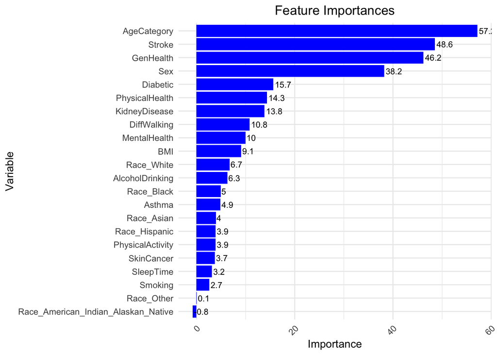

```r
ggplot(importance_df, aes(y = reorder(variable, X1), x = X1)) +
  geom_bar(stat = "identity", fill = "blue") +
  geom_text(aes(label = round(X1,1)), hjust = -0.1, size = 3, color = "black") +
  labs(y = "Variable", x = "Importance") +
  ggtitle("Feature Importances") +
  theme_minimal() +
  theme(plot.title = element_text(hjust = 0.5),
        axis.text.x = element_text(angle = 45, hjust = 1))
```

```r
library(caret)
```

#Define the range of weights to be tested

```r
weight_range <- seq(0.1, 1, by = 0.1)
```

#Initialize an empty dataframe to store results

```r
results_LR <- data.frame(weights = character(),
                         accuracy = numeric(),
                         recall = numeric(),
                         precision = numeric(),
                         f1_score = numeric(),
                         stringsAsFactors = FALSE)
```

#Perform parameter tuning with different class weights

```r
model <- glm(HeartDisease ~ .,
             data = train_set,
             family = "binomial")
class_weights <- 'Default'

for (weight in weight_range) {
  # Train the logistic regression model with class weights


  # Make predictions on the test set
  predictions <- predict(model, newdata = test_set, type = "response")

  # Convert predictions to factors
  predictions <- as.factor(ifelse(predictions > 0.5, 1, 0))

  # Calculate evaluation metrics
  TP <- sum(predictions == 1 & test_set$HeartDisease == 1)
  FN <- sum(predictions == 0 & test_set$HeartDisease == 1)

  accuracy <- mean(predictions == test_set$HeartDisease)
  #recall <- sensitivity(as.factor(test_set$HeartDisease), as.factor(predictions))
  recall <- TP / (TP + FN)
  precision <- sum(predictions == 1 & test_set$HeartDisease == 1) / sum(predictions == 1)
  f1_score <- 2 * (precision * recall) / (precision + recall)

  # Append results to the dataframe

  results_LR <- rbind(results_LR, data.frame(weights = class_weights,
                                             accuracy = accuracy,
                                             recall = recall,
                                             precision = precision,
                                             f1_score = f1_score,
                                             stringsAsFactors = FALSE))

  class_weights <- paste(1 - weight, weight, sep = ":")
  model <- glm(HeartDisease ~ .,
               data = train_set,
               family = "binomial",
               weights = ifelse(train_set$HeartDisease == 1, weight, 1 - weight))
}
# Print the results
print(results_LR)
```

```
##    weights  accuracy       recall precision     f1_score
## 1  Default 0.9161507 0.1132420091 0.5496454 0.1877934272
## 2  0.9:0.1 0.9144153 0.0001826484 1.0000000 0.0003652301
## 3  0.8:0.2 0.9147905 0.0056621005 0.8378378 0.0112481858
## 4  0.7:0.3 0.9154472 0.0235616438 0.6753927 0.0455347688
## 5  0.6:0.4 0.9161664 0.0578995434 0.6084453 0.1057371581
## 6  0.5:0.5 0.9161507 0.1132420091 0.5496454 0.1877934272
## 7  0.4:0.6 0.9140869 0.1961643836 0.4953875 0.2810414759
## 8  0.3:0.7 0.9039556 0.3081278539 0.4173676 0.3545234843
## 9  0.2:0.8 0.8757661 0.4789041096 0.3398574 0.3975739196
## 10 0.1:0.9 0.7791119 0.7364383562 0.2411916 0.3633741889
```